# Geographic analysis of journal articles on climate change economics

Manon Eluard and Loic Henry

2024-07-24

# Introduction

In this analysis, we document the geography of the economics of climate change. In particular, we analyze where and when the economics of climate change has developed as a field. We also bring some explanations to the fact that some countries have provided more analysis on the topic than others.

# Data exploration

```r
library(ggplot2)
library(dplyr)
```

Analyse descriptive

```r
df_final_merged<-read.csv(here(dir$prep_data,"df_final_merged.csv"))

# Check Isle of Man
# Add graph interactifs si intéressant
# Add a variable by 3 regions of the world
# Add map
# Use trend instead of year fixed effects
# Use mega tons of CO2
# Don't forget comparative advantage in regression tables
```

```r
library(corrplot)
# Afficher les noms des variables

names(df_final_merged)
```

```
##  [1] "country"                   "PY"
##  [3] "N_econ"                    "N_CC"
##  [5] "N_TopFive"                 "N_TopTen"
##  [7] "N_Top30"                   "N_TrunkJournals"
##  [9] "N_Top30_CC"                "N_TrunkJournals_CC"
## [11] "mean_TC"                   "mean_nb_authors"
## [13] "mean_nb_authors_gendered"  "mean_share_male_authors"
## [15] "mean_share_female_authors" "N_F"
## [17] "N_M"                       "N_FF"
## [19] "N_MM"                      "N_FM"
## [21] "Share_econ"                "Share_CC"
## [23] "Share_TopFive"             "Share_TopTen"
## [25] "Share_Top30"               "Share_TrunkJournals"
## [27] "Share_Top30_CC"            "Share_TrunkJournals_CC"
## [29] "ISO3"                      "year"
## [31] "PIBValues"                 "RDValues"
## [33] "EducFValues"               "EducHValues"
## [35] "CO2emissionsalues"         "NDC_Implied_average"
## [37] "NDC_Implied_conditional"   "NDC_Implied_unconditional"
## [39] "is_carbon_tax"             "ExpendituresValues"
## [41] "DisastersValues"           "TemperatureValues"
## [43] "Comparative_advantage"     "Total_trade"
## [45] "Trade_balance"
```

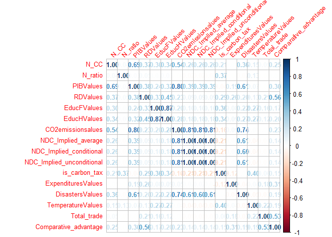

```r
df_final_merged <- df_final_merged %>%
  mutate(NDC_Implied_average=as.numeric(NDC_Implied_average)) %>%
  mutate(NDC_Implied_conditional=as.numeric(NDC_Implied_conditional)) %>%
  mutate(NDC_Implied_unconditional=as.numeric(NDC_Implied_unconditional),
         Total_trade = as.numeric(Total_trade),
         Comparative_advantage = as.numeric(Comparative_advantage),
         Trade_balance = as.numeric(Trade_balance)) %>%
 mutate(DisastersValues=as.numeric(DisastersValues))

df_final_merged$N_ratio <- df_final_merged$N_CC / df_final_merged$N_econ
df_final_merged$N_ratio[is.nan(df_final_merged$N_ratio)] <- NA

# Sélectionner les colonnes spécifiques (ajouter les variables de commerce si besoin)
selected_data <- df_final_merged[,c("N_CC","N_ratio","PIBValues","RDValues","EducFValues","EducHValues","CO2emissionsalues","NDC_Implied_average","NDC_Implied_conditional","NDC_Implied_unconditional","is_carbon_tax","ExpendituresValues","DisastersValues","TemperatureValues", "Total_trade", "Comparative_advantage")]

# Calculer la matrice de corrélation
cor_matrix <- cor(selected_data, use = "pairwise.complete.obs")

# Afficher la matrice de corrélation avec corrplot
corrplot(cor_matrix, method = "number", tl.srt = 45, tl.cex = 0.8, number.cex = 0.8)
```

```r
# Les variables les plus corrélées avec le nombre d'articles sur le changement climatiue sont: le PIB, les émissions de CO2, les dépenses en recherche et développement et le nombre de désastres
```

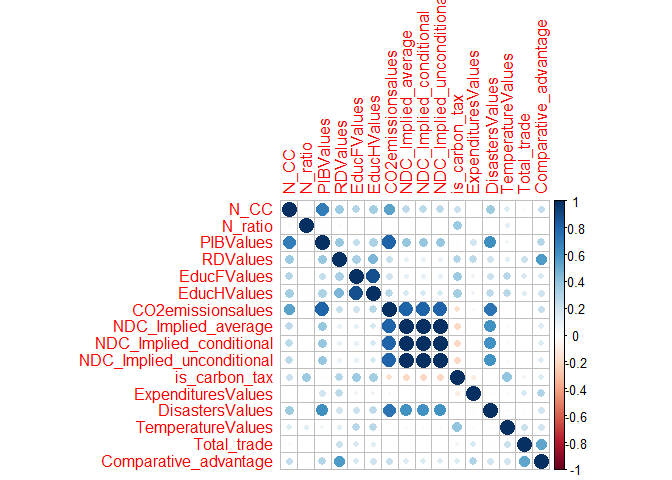

```r
corrplot(cor_matrix)
```

Analyse de corrélation PIB à l’échelle pays

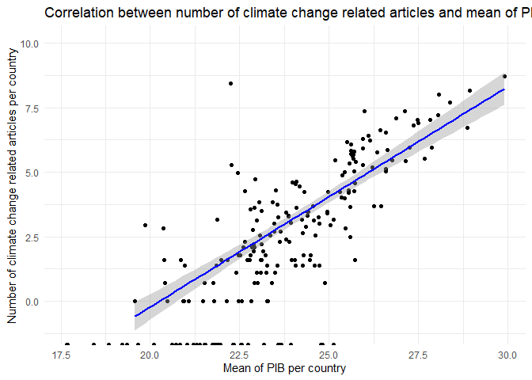

```r
# Calcul des agrégats par pays
df_aggreg_countries_PIB <- df_final_merged %>%
  group_by(country) %>%
  summarize(
    N_CC_country = sum(N_CC, na.rm = TRUE),
    N_eco_country = sum(N_econ, na.rm = TRUE),
    N_ratio = N_CC_country/N_eco_country,
    mean_PIB_country = mean(PIBValues, na.rm = TRUE)
  )

# Remplacer les NaN par NA dans tout le dataframe
df_aggreg_countries_PIB <- df_aggreg_countries_PIB %>%
  mutate(across(everything(), ~ ifelse(is.nan(.), NA, .)))

ggplot(df_aggreg_countries_PIB, aes(x = log(mean_PIB_country), y = log(N_CC_country))) +
  geom_point() +
  geom_smooth(method = "lm", col = "blue") +
  #geom_text(data = filter(df_aggreg_countries_PIB), aes(x=mean_PIB_country), y= N_CC_country, label=country, nudge_x =1, nudge_y=1)+
  labs(title = "Correlation between number of climate change related articles and mean of PIB",
       x = "Mean of PIB per country",
       y = "Number of climate change related articles per country") +
  theme_minimal()
```

Analyse de corrélation PIB à l’échelle agrégée

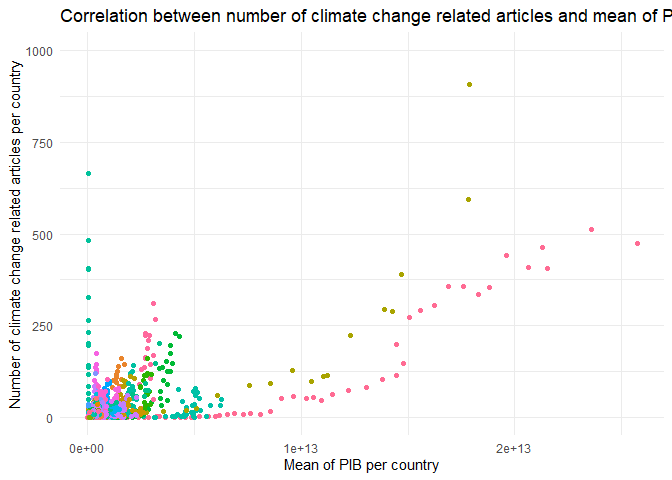

```r
#log?
ggplot(df_final_merged, aes(x = PIBValues, y = N_CC)) +
  geom_point(aes(color=country)) +
  labs(title = "Correlation between number of climate change related articles and mean of PIB",
       x = "Mean of PIB per country",
       y = "Number of climate change related articles per country") +
  theme_minimal()+
  theme(legend.position = "none") +
  ylim(0, 1000)
```

Graphique interractif

```r
#install.packages("ggiraph")
library(ggiraph)
```

```r
plot_interractif <- ggplot(data = df_final_merged) +    geom_point_interactive(aes(x = PIBValues, y = N_CC,    tooltip = ISO3, data_id = ISO3))  +
  theme(legend.position = "none")+ theme_minimal()
girafe(ggobj=plot_interractif)
```

[interactive chart not shown]

Analyse de corrélation PIB et ratio CC à l’échelle désagrégée

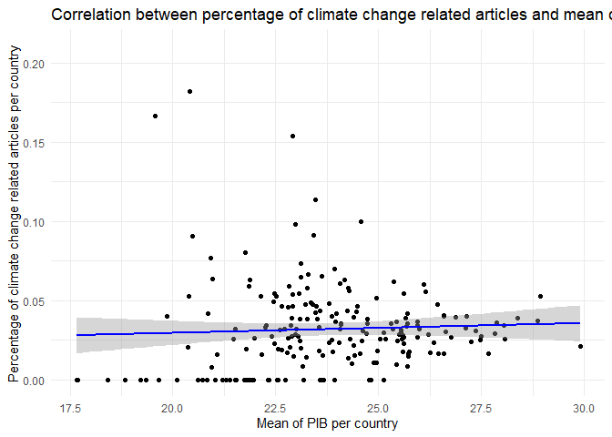

```r
ggplot(df_aggreg_countries_PIB, aes(x = log(mean_PIB_country), y = N_ratio)) +
  geom_point() +
  geom_smooth(method = "lm", col = "blue") +
  #geom_text(data = filter(df_aggreg_countries_PIB), aes(x=mean_PIB_country), y= N_CC_country, label=country, nudge_x =1, nudge_y=1)+
  labs(title = "Correlation between percentage of climate change related articles and mean of PIB",
       x = "Mean of PIB per country",
       y = "Percentage of climate change related articles per country") +
  theme_minimal()
```

```r
##Plus de corrélation
```

Analyse de corrélation CO2

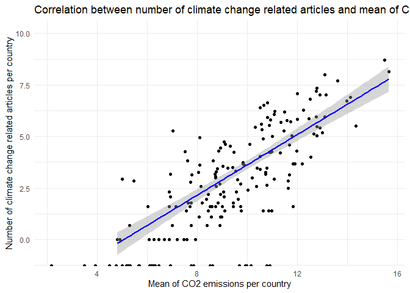

```r
# Calcul des agrégats par pays
df_aggreg_countries_CO2 <- df_final_merged %>%
  group_by(country) %>%
  summarize(
    N_CC_country = sum(N_CC, na.rm = TRUE),
    N_eco_country = sum(N_econ, na.rm = TRUE),
    N_ratio = N_CC_country/N_eco_country,
    mean_CO2_country = mean(CO2emissionsalues, na.rm = TRUE)
  )

# Remplacer les NaN par NA dans tout le dataframe
df_aggreg_countries_CO2 <- df_aggreg_countries_CO2 %>%
  mutate(across(everything(), ~ ifelse(is.nan(.), NA, .)))

ggplot(df_aggreg_countries_CO2, aes(x = log(mean_CO2_country), y = log(N_CC_country))) +
  geom_point() +
  geom_smooth(method = "lm", col = "blue") +
  labs(title = "Correlation between number of climate change related articles and mean of CO2 emissions",
       x = "Mean of CO2 emissions per country",
       y = "Number of climate change related articles per country") +
  theme_minimal()
```

Analyse de corrélation CO2 à l’échelle agrégée

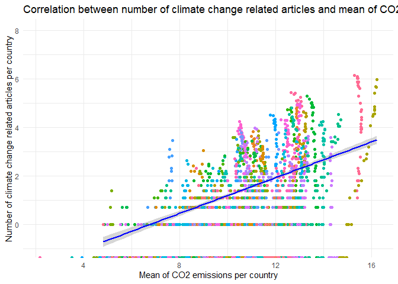

```r
ggplot(df_final_merged, aes(x = log(CO2emissionsalues), y = log(N_CC))) +
  geom_point(aes(color=country)) +
  geom_smooth(method = "lm", col = "blue") +
  labs(title = "Correlation between number of climate change related articles and mean of CO2 emissions",
       x = "Mean of CO2 emissions per country",
       y = "Number of climate change related articles per country") +
  theme_minimal()+
  theme(legend.position = "none")
```

Analyse de corrélation CO2 et ratio CC à l’échelle désagrégée

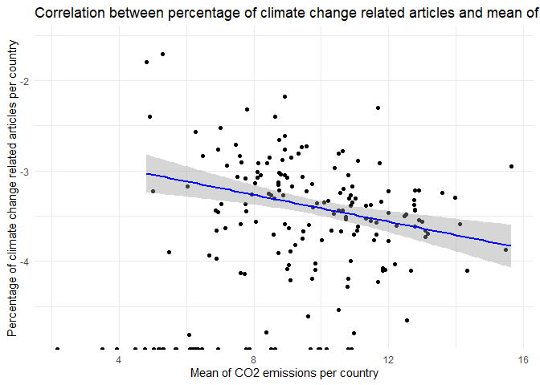

```r
ggplot(df_aggreg_countries_CO2, aes(x = log(mean_CO2_country), y = log(N_ratio))) +
  geom_point() +
  geom_smooth(method = "lm", col = "blue") +
  labs(title = "Correlation between percentage of climate change related articles and mean of CO2 emissions",
       x = "Mean of CO2 emissions per country",
       y = "Percentage of climate change related articles per country") +
  theme_minimal()
```

```r
##Corrélation négative

#Same but animated
```

Analyse de corrélation R&D à l’échelle déségagrégée

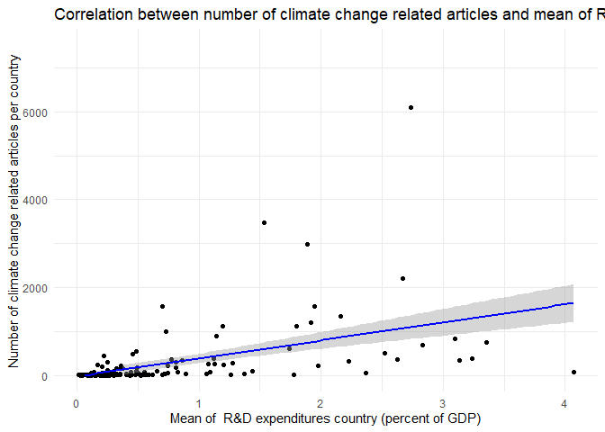

```r
# Calcul des agrégats par pays
df_aggreg_countries_RD <- df_final_merged %>%
  group_by(country) %>%
  summarize(
    N_CC_country = sum(N_CC, na.rm = TRUE),
    N_eco_country = sum(N_econ, na.rm = TRUE),
    N_ratio = N_CC_country/N_eco_country,
    mean_RD_country = mean(RDValues, na.rm = TRUE)
  )

# Remplacer les NaN par NA dans tout le dataframe
df_aggreg_countries_RD <- df_aggreg_countries_RD %>%
  mutate(across(everything(), ~ ifelse(is.nan(.), NA, .)))

ggplot(df_aggreg_countries_RD, aes(x = mean_RD_country, y = N_CC_country)) +
  geom_point() +
  geom_smooth(method = "lm", col = "blue") +
  labs(title = "Correlation between number of climate change related articles and mean of R&D expenditures (percent of GDP)",
       x = "Mean of  R&D expenditures country (percent of GDP)",
       y = "Number of climate change related articles per country") +
  theme_minimal() +
  ylim(0, 7500)
```

```r
## Same but animated
```

Analyse de corrélation R&D expenditures à l’échelle agrégée

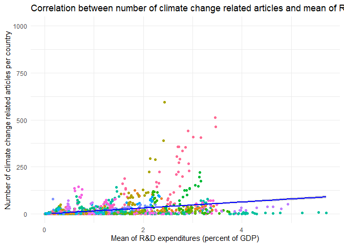

```r
ggplot(df_final_merged, aes(x = RDValues, y = N_CC)) +
  geom_point(aes(color=country)) +
  geom_smooth(method = "lm", col = "blue") +
  labs(title = "Correlation between number of climate change related articles and mean of R&D expenditures (percent of GDP)",
       x = "Mean of R&D expenditures (percent of GDP)",
       y = "Number of climate change related articles per country") +
  theme_minimal()+
  theme(legend.position = "none") +
  ylim(0, 1000)
```

Analyse de corrélation RD et ratio CC à l’échelle désagrégée

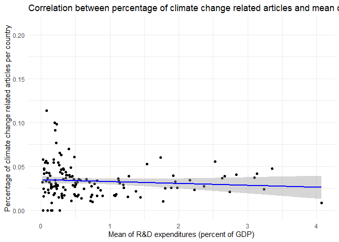

```r
ggplot(df_aggreg_countries_RD, aes(x = mean_RD_country, y = N_ratio)) +
  geom_point() +
  geom_smooth(method = "lm", col = "blue") +
  labs(title = "Correlation between percentage of climate change related articles and mean of R&D expenditures (percent of GDP)",
       x = "Mean of R&D expenditures (percent of GDP)",
       y = "Percentage of climate change related articles per country") +
  theme_minimal()
```

```r
##Corrélation légèrement négative
```

Analyse de corrélation désastres à l’échelle déségagrégée

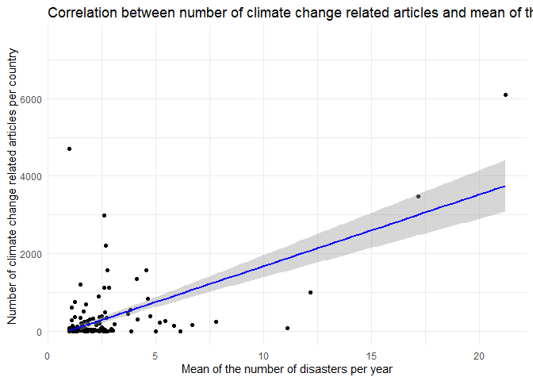

```r
# Calcul des agrégats par pays
df_aggreg_countries_disasters <- df_final_merged %>%
  group_by(country) %>%
  summarize(
    N_CC_country = sum(N_CC, na.rm = TRUE),
    N_eco_country = sum(N_econ, na.rm = TRUE),
    N_ratio = N_CC_country/N_eco_country,
    mean_disasters_country = mean(DisastersValues, na.rm = TRUE)
  )

# Remplacer les NaN par NA dans tout le dataframe
df_aggreg_countries_disasters <- df_aggreg_countries_disasters %>%
  mutate(across(everything(), ~ ifelse(is.nan(.), NA, .)))

ggplot(df_aggreg_countries_disasters, aes(x = mean_disasters_country, y = N_CC_country)) +
  geom_point() +
  geom_smooth(method = "lm", col = "blue") +
  labs(title = "Correlation between number of climate change related articles and mean of the number of disasters per year",
       x = "Mean of the number of disasters per year",
       y = "Number of climate change related articles per country") +
  theme_minimal() +
  ylim(0, 7500)
```

Analyse de corrélation désastres expenditures à l’échelle agrégée

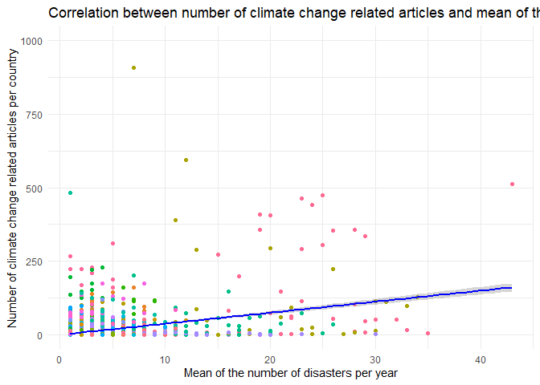

```r
ggplot(df_final_merged, aes(x = DisastersValues, y = N_CC)) +
  geom_point(aes(color=country)) +
  geom_smooth(method = "lm", col = "blue") +
  labs(title = "Correlation between number of climate change related articles and mean of the number of disasters per year",
       x = "Mean of the number of disasters per year",
       y = "Number of climate change related articles per country") +
  theme_minimal() +
  theme(legend.position = "none") +
  ylim(0, 1000)
```

Analyse de corrélation désastres et ratio CC à l’échelle désagrégée

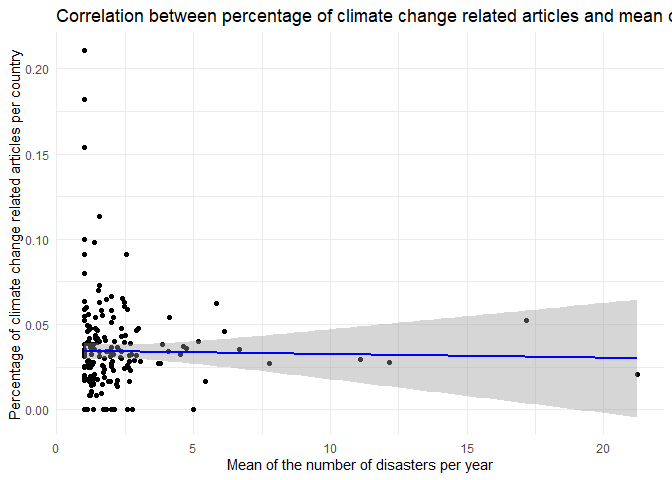

```r
ggplot(df_aggreg_countries_disasters, aes(x = mean_disasters_country, y = N_ratio)) +
  geom_point() +
  geom_smooth(method = "lm", col = "blue") +
  labs(title = "Correlation between percentage of climate change related articles and mean of the number of disasters per year",
       x = "Mean of the number of disasters per year",
       y = "Percentage of climate change related articles per country") +
  theme_minimal()
```

```r
##Faible corrélation
```

Revue de littérature

Article : “The Global distribution of Authorship in Economics Journals”

General idea = Global distribution of authorship in economic journals by country/region, by quality of journal, and by several fields of specialization

Points of methodology:

Measure of the regions : three possible regions for an author’s affiliation = USA ; non-USA advanced economy ; developing economy. Authors are allocated to countries based on the location of their institutional affiliations.

Results - Geographical concentration analysis :

- Comparison between low-income and high-income countries based on the location of the authors
- Regional distribution of authorship in top 10 journals: distribution highly skewed towards the rich regions of the world. This degree of concentration is difficult to explain by economic resources (distribution of the GDP across countries). Imbalance particularly striking for East and South Asia.
- Evolution of regional shares in GDP/frontier economic research over time: USA top 1 since a long time / Gains made by other advanced economies (non-USA advanced). / The problem of under-representation of developing countries in top research publications has been getting worse over time
- Trends in geographical concentration according to different categories of journal quality : The lower the quality raking of a journal, the higher non-USA representation / Non-USA advanced economies have generally made progress across all journal categories / Progress also for developing countries but mainly in the top 100 journal, of lower quality and least prestigious)

### Analyse économétrique

#### Analyse économétrique avec N_CC en variable dépendante

```r
library(lmtest)
library(stargazer)
library(broom)
```

```r
df_final_merged <- df_final_merged %>%
  mutate(PY = as.factor(PY),    # Effet fixe année
         country = as.factor(country),  # Effet fixe journal
         PIB_billion = PIBValues * 10^(-9))
```

```r
model = list()
```

##### Modèle sans effet fixe et avec toutes les variables

```r
model1<- lm(N_CC ~ PIB_billion + RDValues + EducFValues + EducHValues + CO2emissionsalues + NDC_Implied_average + is_carbon_tax + ExpendituresValues + DisastersValues + TemperatureValues + Comparative_advantage, data = df_final_merged) # modèle sans effet fixe

stargazer(model1,
          type = "text")
```

```
##
## =================================================
##                           Dependent variable:
##                       ---------------------------
##                                  N_CC
## -------------------------------------------------
## PIB_billion                    0.039***
##                                 (0.006)
##
## RDValues                         9.853
##                                 (6.389)
##
## EducFValues                     -17.699
##                                (15.586)
##
## EducHValues                    27.798**
##                                (12.778)
##
## CO2emissionsalues             -0.0002***
##                                (0.0001)
##
## NDC_Implied_average            0.362***
##                                 (0.095)
##
## is_carbon_tax                    1.126
##                                 (6.416)
##
## ExpendituresValues               2.289
##                                (10.730)
##
## DisastersValues                 -1.005
##                                 (2.117)
##
## TemperatureValues              -12.493**
##                                 (4.775)
##
## Comparative_advantage           -3.333
##                                 (8.569)
##
## Constant                        -4.315
##                                (11.758)
##
## -------------------------------------------------
## Observations                      133
## R2                               0.663
## Adjusted R2                      0.632
## Residual Std. Error        31.442 (df = 121)
## F Statistic            21.621*** (df = 11; 121)
## =================================================
## Note:                 *p<0.1; **p<0.05; ***p<0.01
```

Coefficients négatifs et significatifs: les émissions de CO2 et le niveau des températures

##### Modèle avec effet fixe pays et avec toutes les variables

```r
model2<- lm(N_CC ~ country + PIB_billion + RDValues + EducFValues + EducHValues + CO2emissionsalues + NDC_Implied_average + is_carbon_tax + ExpendituresValues + DisastersValues + TemperatureValues, data = df_final_merged)

stargazer(model2,
          type = "text",
          keep = c("PIB_billion", "RDValues", "EducFValues", "EducHValues", "CO2emissionsalues", "NDC_Implied_average", "is_carbon_tax", "ExpendituresValues", "DisastersValues", "TemperatureValues"))
```

```
##
## ===============================================
##                         Dependent variable:
##                     ---------------------------
##                                N_CC
## -----------------------------------------------
## PIB_billion                    0.005
##                               (0.019)
##
## RDValues                     22.035**
##                              (11.099)
##
## EducFValues                   -1.889
##                              (13.440)
##
## EducHValues                    8.008
##                              (11.113)
##
## CO2emissionsalues           -0.0003***
##                              (0.0001)
##
## NDC_Implied_average
##
##
## is_carbon_tax                20.392***
##                               (6.211)
##
## ExpendituresValues             8.948
##                              (18.487)
##
## DisastersValues               2.487*
##                               (1.407)
##
## TemperatureValues             -1.374
##                               (3.283)
##
## -----------------------------------------------
## Observations                    133
## R2                             0.899
## Adjusted R2                    0.872
## Residual Std. Error      18.520 (df = 104)
## F Statistic          33.223*** (df = 28; 104)
## ===============================================
## Note:               *p<0.1; **p<0.05; ***p<0.01
```

Coefficients positifs et significatifs: Le fait d’avoir une taxe carbone, la fréquence des désastres, les dépenses en recherche et développement

Coefficients négatifs et significatifs: les émissions de CO2 = modèle sans effet fixe

##### Modèle avec effet fixe pays et années et avec toutes les variables

```r
model3<- lm(N_CC ~ country + PY + PIB_billion + RDValues + EducFValues + EducHValues + CO2emissionsalues + NDC_Implied_average + is_carbon_tax + ExpendituresValues + DisastersValues + TemperatureValues, data = df_final_merged)

stargazer(model3,
          type = "text",
          keep = c("PIB_billion", "RDValues", "EducFValues", "EducHValues", "CO2emissionsalues", "NDC_Implied_average", "is_carbon_tax", "ExpendituresValues", "DisastersValues", "TemperatureValues"))
```

```
##
## ===============================================
##                         Dependent variable:
##                     ---------------------------
##                                N_CC
## -----------------------------------------------
## PIB_billion                    0.004
##                               (0.018)
##
## RDValues                      -1.064
##                               (9.688)
##
## EducFValues                   -8.883
##                              (12.345)
##
## EducHValues                   -1.705
##                              (10.468)
##
## CO2emissionsalues           -0.0005***
##                              (0.0001)
##
## NDC_Implied_average
##
##
## is_carbon_tax                  2.067
##                               (5.873)
##
## ExpendituresValues           47.345***
##                              (17.269)
##
## DisastersValues                1.397
##                               (1.239)
##
## TemperatureValues             -4.741
##                               (3.234)
##
## -----------------------------------------------
## Observations                    133
## R2                             0.944
## Adjusted R2                    0.918
## Residual Std. Error      14.861 (df = 90)
## F Statistic           36.101*** (df = 42; 90)
## ===============================================
## Note:               *p<0.1; **p<0.05; ***p<0.01
```

Coefficients positifs et significatifs: Les dépenses de protection de l’environnement

##### Modèle avec effet fixe pays et années et avec seulement les variables non liées au changement climatique

```r
model4<- lm(N_CC ~ country + PY + PIBValues + RDValues + EducFValues + EducHValues, data = df_final_merged)
stargazer(model4,
          type = "text")
```

```
##
## ==============================================================
##                                        Dependent variable:
##                                    ---------------------------
##                                               N_CC
## --------------------------------------------------------------
## countryAustralia                            23.994**
##                                             (10.204)
##
## countryAustria                                2.642
##                                             (11.472)
##
## countryAzerbaijan                             1.135
##                                              (8.868)
##
## countryBelarus                               -4.430
##                                             (17.666)
##
## countryBelgium                               -3.863
##                                              (9.555)
##
## countryBermuda                                4.922
##                                             (17.678)
##
## countryBolivia                               20.337
##                                             (13.906)
##
## countryBosnia and Herzegovina                -0.882
##                                              (8.533)
##
## countryBrazil                              -43.248***
##                                             (11.805)
##
## countryBrunei Darussalam                      0.905
##                                             (17.616)
##
## countryBulgaria                               3.939
##                                              (7.388)
##
## countryBurkina Faso                           4.170
```

[output cut: 358 more lines]

```
##
## EducHValues                                   4.544
##                                              (3.778)
##
## Constant                                     -0.277
##                                             (14.100)
##
## --------------------------------------------------------------
## Observations                                   825
## R2                                            0.933
## Adjusted R2                                   0.920
## Residual Std. Error                     16.452 (df = 692)
## F Statistic                         73.227*** (df = 132; 692)
## ==============================================================
## Note:                              *p<0.1; **p<0.05; ***p<0.01
```

Aucune variable significative

##### Modèle avec effet fixe pays et années et avec seulement les variables liées au changement climatique

```r
model5<- lm(N_CC ~ country + PY + CO2emissionsalues + NDC_Implied_average + is_carbon_tax + ExpendituresValues + DisastersValues + TemperatureValues, data = df_final_merged)
stargazer(model5,
          type = "text")
```

```
##
## =================================================
##                           Dependent variable:
##                       ---------------------------
##                                  N_CC
## -------------------------------------------------
## countryArgentina               41.892***
##                                (13.015)
##
## countryCanada                 203.592***
##                                (26.322)
##
## countryChile                   27.570**
##                                (10.905)
##
## countryColombia                45.341***
##                                (12.595)
##
## countryDenmark                 37.176***
##                                (13.911)
##
## countryEstonia                  17.995
##                                (17.497)
##
## countryFinland                  47.161*
##                                (24.504)
##
## countryFrance                 153.987***
##                                (20.092)
##
## countryHungary                 41.836***
##                                (12.423)
##
## countryIreland                 39.632***
##                                (12.499)
##
## countryJapan                  334.447***
##                                (51.965)
##
## countryLatvia                  26.278**
```

[output cut: 130 more lines]

```
##
## TemperatureValues              -7.086**
##                                 (2.884)
##
## Constant                      -50.856***
##                                (13.976)
##
## -------------------------------------------------
## Observations                      340
## R2                               0.740
## Adjusted R2                      0.690
## Residual Std. Error        21.876 (df = 284)
## F Statistic            14.725*** (df = 55; 284)
## =================================================
## Note:                 *p<0.1; **p<0.05; ***p<0.01
```

Coefficients positifs et significatifs: Le fait d’avoir une taxe carbone

Coefficients négatifs et significatifs: les émissions de CO2, la hausse des températures

#### Analyse économétrique avec N_ratio en variable dépendante

##### Modèle sans effet fixe et avec toutes les variables

```r
model1<- lm(N_ratio ~ PIB_billion + RDValues + EducFValues + EducHValues + NDC_Implied_average + is_carbon_tax + ExpendituresValues + DisastersValues + TemperatureValues, data = df_final_merged) # modèle sans effet fixe
# vif(mod = model1)vif(mod = model3)
stargazer(model1,
          type = "text",
          keep = c("PIB_billion", "RDValues", "EducFValues", "EducHValues", "CO2emissionsalues", "NDC_Implied_average", "is_carbon_tax", "ExpendituresValues", "DisastersValues", "TemperatureValues"))
```

```
##
## ===============================================
##                         Dependent variable:
##                     ---------------------------
##                               N_ratio
## -----------------------------------------------
## PIB_billion                  -0.00000
##                              (0.00000)
##
## RDValues                     0.009***
##                               (0.003)
##
## EducFValues                   -0.010
##                               (0.007)
##
## EducHValues                    0.008
##                               (0.006)
##
## NDC_Implied_average          -0.00000
##                              (0.00001)
##
## is_carbon_tax                  0.004
##                               (0.003)
##
## ExpendituresValues            0.009*
##                               (0.005)
##
## DisastersValues                0.001
##                               (0.001)
##
## TemperatureValues             -0.004
##                               (0.002)
##
## -----------------------------------------------
## Observations                    143
## R2                             0.228
## Adjusted R2                    0.176
## Residual Std. Error      0.016 (df = 133)
## F Statistic           4.366*** (df = 9; 133)
## ===============================================
## Note:               *p<0.1; **p<0.05; ***p<0.01
```

##### Modèle avec effet fixe pays et avec toutes les variables

```r
model2<- lm(N_ratio ~ country + PIB_billion + RDValues + EducFValues + EducHValues + CO2emissionsalues + NDC_Implied_average + is_carbon_tax + ExpendituresValues + DisastersValues + TemperatureValues, data = df_final_merged)

stargazer(model2,
          type = "text",
          keep = c("PIB_billion", "RDValues", "EducFValues", "EducHValues", "CO2emissionsalues", "NDC_Implied_average", "is_carbon_tax", "ExpendituresValues", "DisastersValues", "TemperatureValues"))
```

```
##
## ===============================================
##                         Dependent variable:
##                     ---------------------------
##                               N_ratio
## -----------------------------------------------
## PIB_billion                   0.00001
##                              (0.00001)
##
## RDValues                      0.012*
##                               (0.007)
##
## EducFValues                   0.020**
##                               (0.008)
##
## EducHValues                   -0.012*
##                               (0.007)
##
## CO2emissionsalues             -0.000
##                              (0.00000)
##
## NDC_Implied_average
##
##
## is_carbon_tax                 0.008**
##                               (0.004)
##
## ExpendituresValues           0.039***
##                               (0.011)
##
## DisastersValues                0.001
##                               (0.001)
##
## TemperatureValues             -0.0001
##                               (0.002)
##
## -----------------------------------------------
## Observations                    133
## R2                             0.667
## Adjusted R2                    0.577
## Residual Std. Error      0.011 (df = 104)
## F Statistic           7.424*** (df = 28; 104)
## ===============================================
## Note:               *p<0.1; **p<0.05; ***p<0.01
```

Coefficients positifs et significatifs: Les dépenses en recherche et développement, le niveau d’éducation des femmes, le fait d’avoir une taxe carbone les dépenses de protection de l’environnement

Coefficients négatifs et significatifs: le niveau d’éducation des hommes

##### Modèle avec effet fixe pays et années et avec toutes les variables

```r
model3<- lm(N_ratio ~ country + PY + PIB_billion + RDValues + EducFValues + EducHValues + CO2emissionsalues + NDC_Implied_average + is_carbon_tax + ExpendituresValues + DisastersValues + TemperatureValues, data = df_final_merged)
library(car)
stargazer(model3,
          type = "text",
          keep = c("PIB_billion", "RDValues", "EducFValues", "EducHValues", "CO2emissionsalues", "NDC_Implied_average", "is_carbon_tax", "ExpendituresValues", "DisastersValues", "TemperatureValues"))
```

```
##
## ===============================================
##                         Dependent variable:
##                     ---------------------------
##                               N_ratio
## -----------------------------------------------
## PIB_billion                   0.00001
##                              (0.00001)
##
## RDValues                       0.002
##                               (0.007)
##
## EducFValues                  0.022***
##                               (0.008)
##
## EducHValues                  -0.021***
##                               (0.007)
##
## CO2emissionsalues            -0.00000
##                              (0.00000)
##
## NDC_Implied_average
##
##
## is_carbon_tax                  0.004
##                               (0.004)
##
## ExpendituresValues           0.054***
##                               (0.012)
##
## DisastersValues                0.001
##                               (0.001)
##
## TemperatureValues             0.0003
##                               (0.002)
##
## -----------------------------------------------
## Observations                    133
## R2                             0.771
## Adjusted R2                    0.664
## Residual Std. Error       0.010 (df = 90)
## F Statistic           7.216*** (df = 42; 90)
## ===============================================
## Note:               *p<0.1; **p<0.05; ***p<0.01
```

Coefficients positifs et significatifs: Le niveau d’éduction des femmes et les dépenses de protection de l’environnement

Coefficients négatifs et significatifs: le niveau d’éducation des hommes

##### Modèle avec effet fixe pays et années et avec seulement les variables non liées au changement climatique

```r
model4 <- lm(N_ratio ~ country + PY + PIBValues + RDValues + EducFValues + EducHValues, data = df_final_merged)
stargazer(model4,
          type = "text")
```

```
##
## ==============================================================
##                                        Dependent variable:
##                                    ---------------------------
##                                              N_ratio
## --------------------------------------------------------------
## countryAustralia                             0.031**
##                                              (0.014)
##
## countryAustria                              0.068***
##                                              (0.016)
##
## countryAzerbaijan                            0.025**
##                                              (0.012)
##
## countryBelarus                               0.055**
##                                              (0.025)
##
## countryBelgium                               0.033**
##                                              (0.013)
##
## countryBermuda                                0.001
##                                              (0.025)
##
## countryBolivia                                0.011
##                                              (0.019)
##
## countryBosnia and Herzegovina                -0.002
##                                              (0.012)
##
## countryBrazil                                0.037**
##                                              (0.017)
##
## countryBrunei Darussalam                    0.120***
##                                              (0.025)
##
## countryBulgaria                              0.018*
##                                              (0.010)
##
## countryBurkina Faso                         0.101***
```

[output cut: 358 more lines]

```
##
## EducHValues                                   0.006
##                                              (0.005)
##
## Constant                                     -0.021
##                                              (0.020)
##
## --------------------------------------------------------------
## Observations                                   825
## R2                                            0.413
## Adjusted R2                                   0.302
## Residual Std. Error                     0.023 (df = 692)
## F Statistic                         3.696*** (df = 132; 692)
## ==============================================================
## Note:                              *p<0.1; **p<0.05; ***p<0.01
```

Aucune variable significative

##### Modèle avec effet fixe pays et années et avec seulement les variables liées au changement climatique

```r
model5 <- lm(N_ratio ~ country + PY + CO2emissionsalues + NDC_Implied_average + is_carbon_tax + ExpendituresValues + DisastersValues + TemperatureValues, data = df_final_merged)
stargazer(model5,
          type = "text")
```

```
##
## =================================================
##                           Dependent variable:
##                       ---------------------------
##                                 N_ratio
## -------------------------------------------------
## countryArgentina               0.020***
##                                 (0.007)
##
## countryCanada                   0.025*
##                                 (0.015)
##
## countryChile                   0.031***
##                                 (0.006)
##
## countryColombia                0.031***
##                                 (0.007)
##
## countryDenmark                 0.025***
##                                 (0.008)
##
## countryEstonia                 0.028***
##                                 (0.010)
##
## countryFinland                 0.053***
##                                 (0.014)
##
## countryFrance                   0.028**
##                                 (0.012)
##
## countryHungary                 0.025***
##                                 (0.007)
##
## countryIreland                 0.033***
##                                 (0.007)
##
## countryJapan                     0.023
##                                 (0.030)
##
## countryLatvia                   0.017**
```

[output cut: 130 more lines]

```
##
## TemperatureValues               -0.002
##                                 (0.002)
##
## Constant                       -0.020**
##                                 (0.008)
##
## -------------------------------------------------
## Observations                      340
## R2                               0.632
## Adjusted R2                      0.560
## Residual Std. Error        0.013 (df = 284)
## F Statistic             8.859*** (df = 55; 284)
## =================================================
## Note:                 *p<0.1; **p<0.05; ***p<0.01
```

Coefficients positifs et significatifs: Le fait d’avoir une taxe carbone

#### Comparaison des modèles économétriques

##### Comparaison des modèles économétriques avec N_CC la variable dépendante

Globalement, les émissions de CO2 ont un impact négatif et significatif dans tous les modèles, ce qui signifie que les pays qui émettent le plus sont aussi les pays qui publient le moins d’articles sur le changement climatique.

##### Comparaison des modèles économétriques selon la variable dépendante

Dans les deux cas, lorsque l’on fait la régression avec effet fixe pays et années et avec toutes les variables, **le niveau des dépenses de protection de l’environnement** a toujours un impact positif et significatif sur le nombre d’articles écrits qui portent sur le changement climatique ou sur son ratio.

Dans les deux cas, lorsque l’on fait une régression seulement avec les variables qui n’ont aucun lien avec le changement climatique, aucune de ces variables n’est significative.

Dans les deux cas, lorsque l’on fait une régression seulement avec les variables qui ont un lien avec le changement climatique, **le fait d’avoir une taxe carbone** a toujours un impact positif et significatif sur le nombre d’articles écrits qui portent sur le changement climatique ou sur son ratio.

Globalement, les dépenses de protection de l’environnement et le fait d’avoir une taxe carbone sont des variables qui ont souvent un coefficient positif et significatif.

```r
# ### Faire une carte
# # Ajout de la colonne geometry : Créer un shapefile (une data frame géospatialisée)
# # Install and load necessary packages
#
# install.packages("sf")
# install.packages("rnaturalearth")
# install.packages("rnaturalearthdata")
#
# library(sf)
# library(rnaturalearth)
# library(rnaturalearthdata)
#
# # Get the world country polygons
# world <- ne_countries(scale = "medium", returnclass = "sf") %>%
#   mutate(ISO3 = iso_a3_eh)
#
# str(world)
# # Add ISO3 variable to merge world and aggreg df country (not needed if already iso3)
# temp <- countries::country_reference_list
# association_table <- temp %>%
#   select(Name0, ISO3, simple) %>%
#   mutate(Country.Code = ISO3) %>%
#   select(ISO3,Name0) %>%
#   rename(country=Name0)
#
# df_aggreg_countries_ISO3 <- df_aggreg_countries %>%
#   left_join(association_table,by="country")
#
# # Merge the data frame with the geometries
# sf_aggreg_countries_ISO3 <- df_aggreg_countries_ISO3 %>%
#   left_join(world, by = "ISO3") %>%
#   st_as_sf()
#
# ggplot(sf_aggreg_countries_ISO3) +
#   geom_sf(aes(fill=N_CC_country))
```